# Logistic Regression: Collinearity, Model Fit, and Prediction Accuracy

Lecture 3D

PUBHBIO 6250

## Collinearity

- Highly correlated variables can inflate standard errors in logistic regression.
  - Inflated standard errors $\rightarrow$ larger $p$-values and wider confidence intervals
  - If standard errors are huge, collinearity could be present.
  - Compute Pearson correlations between predictors to identify the culprits.
- Highly correlated variables could carry similar information.
- Do not include variables with redundant information in the same model.
  - Choose the one that is more biologically/scientifically important or that is a better predictor of the outcome.
  - In practice, choose the one that is cheaper or easier to measure.

## Collinearity: A Case Study

**Study on Efficacy of Nosocomial Infection Control (SENIC)**

- **Objective**: Assess whether infection surveillance and control programs reduce rates of hospital-acquired infections (“nosocomial” = hospital-acquired)
- **Data**:
  - 113 of the 338 U.S. hospitals surveyed.
  - two predictors: # beds and # patients/day
- **Data analysis results**:
  - # beds ($p$-value = 0.075) and # patients/day ($p$-value = 0.037) are both **positively related** with the odds that a hospital has an infection rate $>5\%$.
  - When both are included in the model, their statistical significance decreases
    - $p$-value = 0.158 for # beds; $p$-value = 0.082 for # patients/day
  - What’s going on? *Hint: the answer is on the next slide*

## Collinearity: Case Study Output

- Results from univariate models

| Univariate model | Predictor | Estimate | Std. error |
| --- | --- | --- | --- |
| # beds only | # beds | 0.0018544 | 0.0010424 |
| # patients/day only | # patients/day | 0.0027651 | 0.0013275 |

- Results from model includes both # beds and # patients/day

| Predictor | Estimate | Std. error |
| --- | --- | --- |
| # beds | -0.0086527 | 0.0061356 |
| # patients/day | 0.0135184 | 0.0077777 |

- Inflated standard errors are observed when both predictors are included.
- Change in the sign of the log-odds associated with # beds.
- Pearson correlation is $\hat{\rho}_{\text{beds, patients}} = 0.9810$ $\rightarrow$ two predictors are related.
  - # patients that can be admitted reflects # beds

## Model Fit: Likelihood of Model

- Likelihood measures how probable the observed data are given the model.

  $\rightarrow$ Larger values of likelihood or log-likelihood suggest better fit
- Likelihood is not an ideal measure of fit, as it always increases with the number of predictors included.
- Likelihood ratio test tells if adding predictors significantly improves likelihood.
  - If we reject the null hypothesis, the larger model is preferred.
  - If we fail to reject the null hypothesis, the smaller model is preferred.

## Measures of Model Fit

    e.g., For $n = 8$, $\log(8) > 2$.
  - Models with **smaller** BIC are preferred.

## Hosmer-Lemeshow Test

- Hosmer-Lemeshow test is a formal test of goodness of fit of model.
- **Approach**
1. Partition subjects into $K$ groups by ordered estimates of success probabilities.
   - Estimate success probabilities using the following equation:

$$\hat{P}(\boldsymbol{x}) = \frac{\exp\{\hat{\beta}_0+\hat{\beta}_1x_1+\cdots+\hat{\beta}_px_p\}}{1+\exp\{\hat{\beta}_0+\hat{\beta}_1x_1+\cdots+\hat{\beta}_px_p\}}$$

- $K=10$ is typically used; group boundaries are based on deciles of $\hat{P}(\boldsymbol{x})$.

## Hosmer-Lemeshow Test (Cont’d)

2. Within each of the $K$ groups, compute Pearson chi-square statistic.

$$\hat{C}=\sum_{j=1}^K\frac{(O_j-E_j)^2}{E_j(1-E_j/n_j)}$$

- $j$ is the group index, $j = 1, \dots, K$
- $n_j$ = number of observations in group $j$
- $O_j$ = observed number of successes in group $j$
- $E_j$ = expected number of successes based on the model in group $j$
  - $E_j= n_j \times (\text{average } \hat{P}(\boldsymbol{x}) \text{ in group } j)$
- $\hat{C}$ is Pearson chi-square test

## Hosmer-Lemeshow Test (Cont’d)

3. Draw conclusions based on the test statistic

   **Hypotheses**
   - $H_0:$ observed success frequency in each group = expected frequency based on model (i.e., model fits the data) $\Leftrightarrow$ The model fits
   - $H_1$: The model does not fit

   **Distribution of the test statistic under $H_0$**: $\hat{C} \sim \chi^2_{K-2}$

   **Conclusion**: Reject $H_0$ if $\hat{C} > \chi^2_{K-2, 1-\alpha}$

   e.g., For $K = 10$ and $\alpha = 0.05$, the critical value, $\chi^2_{8, 0.95}$, is $15.5$.

**Conclusion in the context of goodness of fit**

- Reject $H_0 \rightarrow$ conclude the model **does not fit** the data well.
- Fail to reject $H_0 \rightarrow$ no evidence that the model does not fit the data

## Hosmer-Lemeshow Example

For our selected CHD model, subjects are sorted by their $\hat{p}$ into 10 groups.

[output not shown]

- $n=$ 3152 and $K = 10$
- 1st group = 10% of the subjects with the lowest $\hat{p}$.
- 10th group = 10% of the subjects with the highest $\hat{p}$.
- **Hosmer-Lemeshow test statistic**: $\hat{C} = 9.16$, $DF = 8 \rightarrow$ $p$-value = 0.3288
- **Conclusion**: Fail to reject $H_0$, there is insufficient evidence that the model does not fit.

## H-L Test: What if Reject the Null?

What if we reject $H_0$?

- Model for $P(\boldsymbol{X})$ is incorrect.
- **Possible reasons**
  - Logit is not a linear function of the predictors.

    i.e., $\text{logit}(P(\boldsymbol{X})) = \log\left(\frac{P(\boldsymbol{X})}{1 - P(\boldsymbol{X})}\right)$ is not a linear function of $\boldsymbol{X}$.

    **Solution**: transform continuous predictors or add polynomial terms.
  - Logistic regression is the wrong model.

    **Solution**: try model with different link function
    - probit link: $\Phi^{-1}\left(P(X)\right) = \beta_0 + \beta_1 X$, where $\Phi^{-1}(\cdot)$ inverse of the cumulative distribution function of the standard normal distribution.
    - complementary log-log link: $\log \left( -\log \left[ 1- P(X) \right]\right) = \beta_0 + \beta_1 X$

## H-L Test: Warning

- **Critique**: H-L test is very powerful for large $n$.
  - When $n$ is large, H-L test frequently rejects $H_0$.
  - When $n$ is large, H-L test may suggest that a very good (but not perfect) model does not fit the data.
- To address this issue, suggest increasing $K$.

  See paper by Paul, Pennell, and Lemeshow (*Statistics in Medicine*, Vol 32, p. 67-80, 2013).
- Plot of observed vs. expected number of events is also informative as departures from a straight-line relationship indicate where the model is not working well.

## Prediction Accuracy

- Suppose we want to use our CHD model to determine if a future patient is likely to develop CHD and thus require extra care (prediction).
- A threshold $\tau$ (e.g., $\tau = 0.5$) is needed.
  - Subjects with $\hat{P}(\boldsymbol{X})>\tau$ are classified as likely to develop CHD.
- Accuracy of classification can then be measured by:
  - **Sensitivity:** Proportion of subjects with CHD with $\hat{P}(\boldsymbol{X}_i)>\tau$.
  - **Specificity:** Proportion of subjects without CHD with $\hat{P}(\boldsymbol{X}_i) \le \tau$.

## Prediction Accuracy: ROC Curve

- Sensitivity and specificity are dependent on the threshold $\tau$.
  - Not a great overall measure of prediction accuracy!
- A better approach is to use a Receiver Operating Characteristic (ROC) Curve.
  - Plot of sensitivity vs. (1 - specificity) for all possible threshold values $\tau$.
  - Compared to the diagonal line = what you would get from a coin flip.
  - **The closer the curve is to the top and left margins of the plot, the better.**

## Example ROC

Fitted model: $g(\boldsymbol{x})=\beta_0+\beta_1\texttt{age}+\beta_2\texttt{chol}+\beta_3\texttt{behpat2}+\beta_4\texttt{behpat3}+\beta_5\texttt{behpat4}$

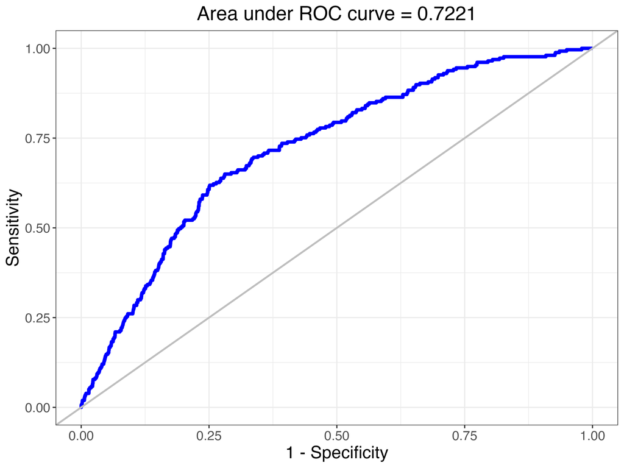

- The diagonal line = what we would expect if randomly guessing the outcome.
- area under the diagonal line = 0.5
- area under the ROC curve = 0.7221

## Prediction Accuracy: Area Under the Curve

- Classification performance measured by **A**rea **U**nder the ROC **C**urve (AUC, also called the C-statistic)
  - AUC = likelihood that subject with disease will have higher $\hat{P}(\boldsymbol{X}_i)$ than subject without disease.
- **Rules of Thumb** (Hosmer et al., p. 177):

| AUC | Interpretation |
| --- | --- |
| AUC $=0.5$ | Model doesn’t discriminate disease from no disease (same as coin flip) |
| $0.5 < \text{AUC} < 0.7$ | Poor discrimination |
| $0.7 \leq\text{AUC} < 0.8$ | Acceptable discrimination |
| $0.8 \leq\text{AUC} < 0.9$ | Excellent discrimination |
| $\text{AUC} \geq 0.9$ | Outstanding discrimination |

## Prediction Accuracy: Choosing a Threshold

Sensitivity and Specificity Curves may be used to select an appropriate $\tau$ for classifying future patients.

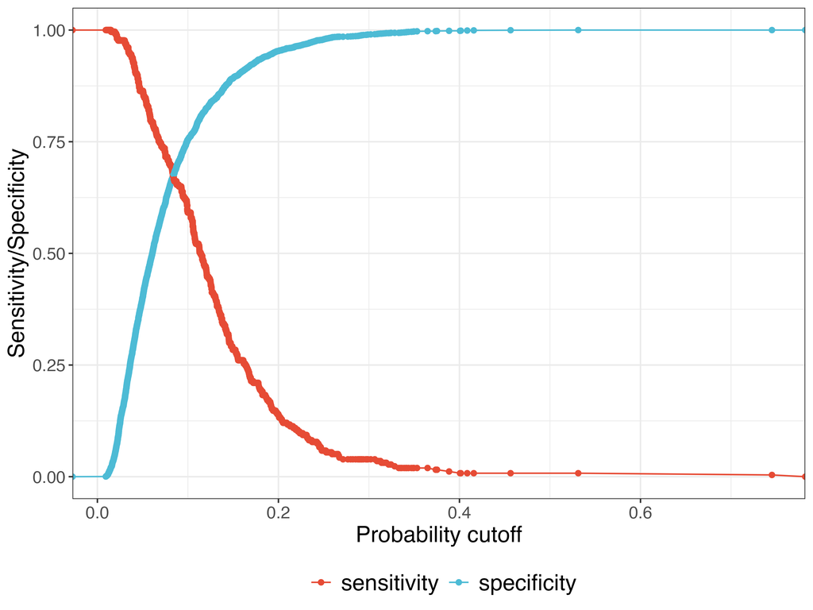

Two approaches for selection:

1. Use $\tau$ which achieves a desired level of sensitivity or specificity.
2. Use intersection of sensitivity and specificity curves.
   - This is the value of $\tau$ which maximizes both sensitivity and specificity.

## Sample Size Issues

- As in linear regression, we don’t want to over-fit in multiple logistic regression.
- The number of “events” determines the amount of information we have.
  - An event is either $Y=1$ or $Y=0$ – whichever is less common in the dataset
- **Rule of thumb**:
  - There must be 10 events per predictor in the model.
  - *Example*

    For 5 predictors, we want to have $\ge 50$ observations in the less common class.
  - Should be used as a guideline rather than a hard rule.